# Case 3: Lake Water Quality Data Analytics

David Ramotowski

2023-02-19

All data was obtained from the Iowa DNR AquIA water quality database and the Cooperative Lakes Area Monitoring Project (CLAMP) database:

- https://programs.iowadnr.gov/aquia/Programs/Lakes
- http://clamp1909.blogspot.com/

Data for the last 20 years in the Iowa Great Lakes (Big Sprit Lake, West Okoboji Lake, East Okoboji Lake) was downloaded from AquIA in csv format:

- **Big Spirit Lake:** ID#22300014
- **West Okoboji Lake:** ID#22300009
- **East Okoboji Lake:** ID#22300008

# **1.)**

Classify the trophic state of the lakes based on the last 20 years of data and describe whether the data indicates that the lakes are stable or show signs of change.

- First, load all required R packages (I mainly use the Tidyverse for dealing with large datasets)

```r
library(tidyverse)
```

```r
library(ggplot2)
```

- Then, I loaded the data for each lake into R:

```r
bsl <- read.csv("big-spirit-lake.csv") #Big Spirit Lake
wol <- read.csv("west_okoboji_lake.csv") #West Okoboji Lake
eol <- read.csv("east_okoboji_lake.csv") #East Okoboji Lake

head(bsl) #inspect data format for one of the files
```

```
##   facilityID   siteID            name    county     huc8 type aquifer latitude
## 1          6 22300014 Big Spirit Lake Dickinson 10230003 Lake      NA 43.48076
## 2          6 22300014 Big Spirit Lake Dickinson 10230003 Lake      NA 43.48076
## 3          6 22300014 Big Spirit Lake Dickinson 10230003 Lake      NA 43.48076
## 4          6 22300014 Big Spirit Lake Dickinson 10230003 Lake      NA 43.48076
## 5          6 22300014 Big Spirit Lake Dickinson 10230003 Lake      NA 43.48076
## 6          6 22300014 Big Spirit Lake Dickinson 10230003 Lake      NA 43.48076
##   longitude                sampleDate projectCode       cas_rn
## 1 -95.08332 2005-06-01T09:45:00-05:00 AMBLAKE-SHL           PH
## 2 -95.08332 2005-06-01T09:45:00-05:00 AMBLAKE-SHL          TDS
## 3 -95.08332 2005-06-01T09:45:00-05:00 AMBLAKE-SHL    7782-44-7
## 4 -95.08332 2005-06-01T09:45:00-05:00 AMBLAKE-SHL DEPTH-BOTTOM
## 5 -95.08332 2005-06-01T09:45:00-05:00 AMBLAKE-SHL DEPTH-SECCHI
## 6 -95.08332 2005-06-01T09:45:00-05:00 AMBLAKE-SHL   TEMP-WATER
##                    analyte  fraction relDepth result  unit detect detectLimit
```

[output cut: 20 more lines]

- I edited the sampleDate column in each dataset to separate out the year and date (mm/dd), I then removed all years before 2002 to only show data for the last 20 years:

```r
bsl <- extract(bsl, "sampleDate", c("Year", "Date"), regex = '(^[0-9]{4})\\D(.{5})') %>% filter(Year>2001)
wol <- extract(wol, "sampleDate", c("Year", "Date"), regex = '(^[0-9]{4})\\D(.{5})') %>% filter(Year>2001)
eol <- extract(eol, "sampleDate", c("Year", "Date"), regex = '(^[0-9]{4})\\D(.{5})') %>% filter(Year>2001)

head(bsl) #Inspect the data for Big Spirit Lake
```

```
##   facilityID   siteID            name    county     huc8 type aquifer latitude
## 1          6 22300014 Big Spirit Lake Dickinson 10230003 Lake      NA 43.48076
## 2          6 22300014 Big Spirit Lake Dickinson 10230003 Lake      NA 43.48076
## 3          6 22300014 Big Spirit Lake Dickinson 10230003 Lake      NA 43.48076
## 4          6 22300014 Big Spirit Lake Dickinson 10230003 Lake      NA 43.48076
## 5          6 22300014 Big Spirit Lake Dickinson 10230003 Lake      NA 43.48076
## 6          6 22300014 Big Spirit Lake Dickinson 10230003 Lake      NA 43.48076
##   longitude Year  Date projectCode       cas_rn                  analyte
## 1 -95.08332 2005 06-01 AMBLAKE-SHL           PH                       pH
## 2 -95.08332 2005 06-01 AMBLAKE-SHL          TDS   Total dissolved solids
## 3 -95.08332 2005 06-01 AMBLAKE-SHL    7782-44-7    Dissolved oxygen (DO)
## 4 -95.08332 2005 06-01 AMBLAKE-SHL DEPTH-BOTTOM            Depth, bottom
## 5 -95.08332 2005 06-01 AMBLAKE-SHL DEPTH-SECCHI Depth, Secchi disk depth
## 6 -95.08332 2005 06-01 AMBLAKE-SHL   TEMP-WATER       Temperature, water
##    fraction relDepth result  unit detect detectLimit quantFlag quantLimit
## 1     Total             8.5  None   True          NA                   NA
## 2 Dissolved           300.0  mg/l   True          NA                   NA
## 3     Total            10.4  mg/l   True        0.10                   NA
## 4     Total             7.4     m   True          NA                   NA
## 5     Total             3.1     m   True        0.01                   NA
## 6     Total            16.0 deg C   True        0.00                   NA
##     method colMethod resultType matrix medium qualFlag remark
## 1   4500-H               Actual     SW  Water       NA     NA
## 2 HYDROLAB           Calculated     SW  Water       NA     NA
## 3  Unknown               Actual     SW  Water       NA     NA
## 4  Unknown               Actual     SW  Water       NA     NA
## 5  Unknown               Actual     SW  Water       NA     NA
## 6  Unknown               Actual     SW  Water       NA     NA
```

- I then subset the data for each lake into separate tables for chl-a:

```r
bsl_chla <- filter(bsl, grepl('Chlorophyll', analyte))
eol_chla <- filter(eol, grepl('Chlorophyll', analyte))
wol_chla <- filter(wol, grepl('Chlorophyll', analyte))

head(bsl_chla) #inspect data for Big Spirit Lake
```

```
##   facilityID   siteID            name    county     huc8 type aquifer latitude
## 1          6 22300014 Big Spirit Lake Dickinson 10230003 Lake      NA 43.48076
## 2          6 22300014 Big Spirit Lake Dickinson 10230003 Lake      NA 43.48076
## 3          6 22300014 Big Spirit Lake Dickinson 10230003 Lake      NA 43.48076
## 4          6 22300014 Big Spirit Lake Dickinson 10230003 Lake      NA 43.48076
## 5          6 22300014 Big Spirit Lake Dickinson 10230003 Lake      NA 43.48076
## 6          6 22300014 Big Spirit Lake Dickinson 10230003 Lake      NA 43.48076
##   longitude Year  Date projectCode     cas_rn                           analyte
## 1 -95.08332 2005 06-01 AMBLAKE-SHL CLR-A-FREE Chlorophyll a, free of pheophytin
## 2 -95.08332 2005 08-02 AMBLAKE-SHL CLR-A-FREE Chlorophyll a, free of pheophytin
## 3 -95.08332 2005 09-27 AMBLAKE-SHL CLR-A-FREE Chlorophyll a, free of pheophytin
## 4 -95.08332 2006 07-18 AMBLAKE-SHL CLR-A-FREE Chlorophyll a, free of pheophytin
## 5 -95.08332 2006 04-25 AMBLAKE-SHL CLR-A-FREE Chlorophyll a, free of pheophytin
## 6 -95.08332 2006 06-06 AMBLAKE-SHL CLR-A-FREE Chlorophyll a, free of pheophytin
##   fraction relDepth result unit detect detectLimit quantFlag quantLimit method
## 1  NonFilt               5 ug/l   True           1                   NA    445
## 2  NonFilt              66 ug/l   True           1                   NA    445
## 3  NonFilt              33 ug/l   True           1                   NA    445
## 4  NonFilt              11 ug/l   True           1                   NA    445
## 5  NonFilt              17 ug/l   True           1                   NA    445
## 6  NonFilt               5 ug/l   True           1                   NA    445
##   colMethod resultType matrix medium qualFlag remark
## 1   UHLLAKE     Actual     SW  Water       NA     NA
## 2   UHLLAKE     Actual     SW  Water       NA     NA
## 3   UHLLAKE     Actual     SW  Water       NA     NA
## 4   UHLLAKE     Actual     SW  Water       NA     NA
## 5   UHLLAKE     Actual     SW  Water       NA     NA
## 6   UHLLAKE     Actual     SW  Water       NA     NA
```

- Calculated average chl-a concentrations in each lake for the past 20 years:

```r
mean(bsl_chla$result) #Big Spirit Lake
```

```
## [1] 18.41377
```

```r
mean(eol_chla$result) #East Okoboji Lake
```

```
## [1] 22.88906
```

```r
mean(wol_chla$result) #West Okoboji Lake
```

```
## [1] 3.657118
```

**Big Spirit Lake**

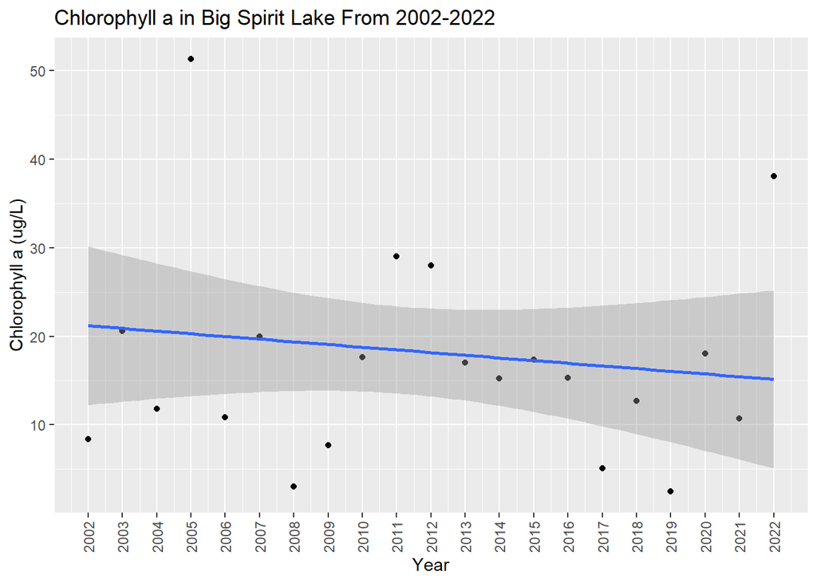

```r
bsl_chla_plot <- ggplot(bsl_chla, aes(x=as.numeric(Year), y=as.numeric(result))) + stat_summary(fun.y = "mean", geom = "point") + ylab("Chlorophyll a (ug/L)") + xlab("Year") + theme(axis.text.x = element_text(angle = 90, vjust = 0.5, hjust=1)) + ggtitle("Chlorophyll a in Big Spirit Lake From 2002-2022") + geom_smooth(method=lm) + scale_x_continuous(breaks = seq(2002, 2022, 1))
bsl_chla_plot
```

- Big Spirit Lake appears to be stable.

**East Okoboji Lake**

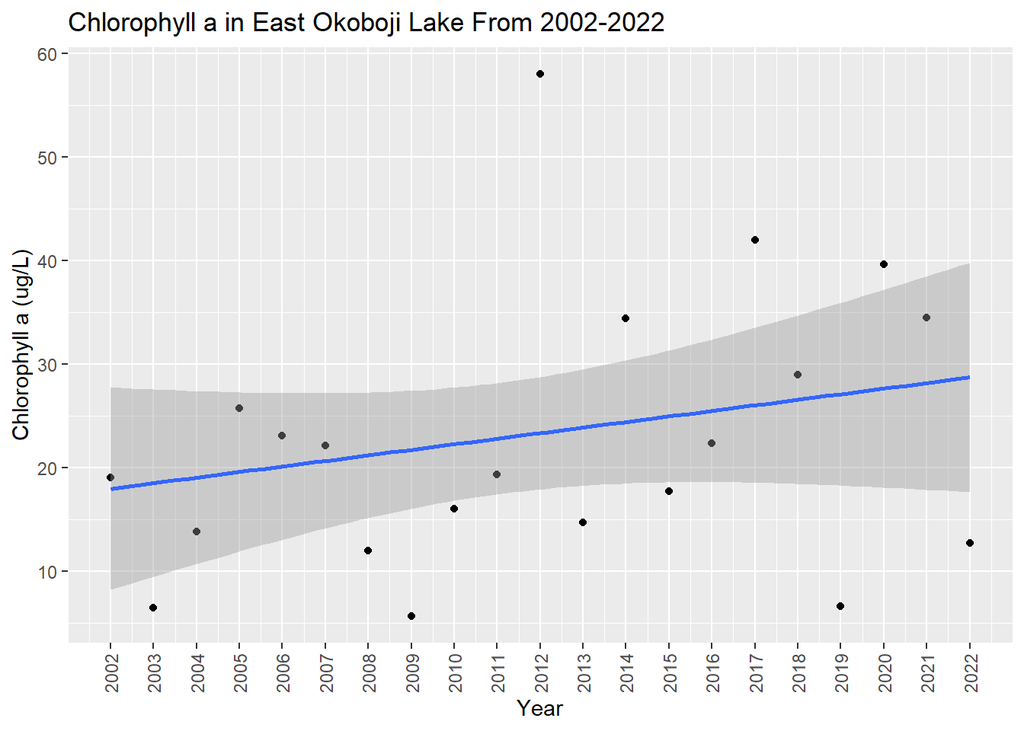

```r
eol_chla_plot <- ggplot(eol_chla, aes(x=as.numeric(Year), y=as.numeric(result))) + stat_summary(fun.y = "mean", geom = "point") + ylab("Chlorophyll a (ug/L)") + xlab("Year") + theme(axis.text.x = element_text(angle = 90, vjust = 0.5, hjust=1)) + ggtitle("Chlorophyll a in East Okoboji Lake From 2002-2022") + geom_smooth(method=lm) + scale_x_continuous(breaks = seq(2002, 2022, 1))


eol_chla_plot
```

- East Okoboji Lake appears to be showing signs of increasing chl-a over time.

**West Okoboji Lake**

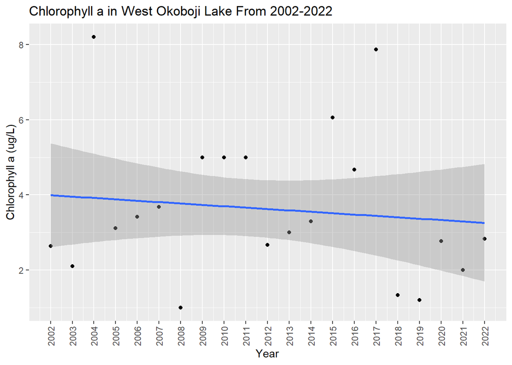

```r
wol_chla_plot <- ggplot(wol_chla, aes(x=as.numeric(Year), y=as.numeric(result))) + stat_summary(fun.y = "mean", geom = "point") + ylab("Chlorophyll a (ug/L)") + xlab("Year") + theme(axis.text.x = element_text(angle = 90, vjust = 0.5, hjust=1)) + ggtitle("Chlorophyll a in West Okoboji Lake From 2002-2022") + geom_smooth(method=lm) + scale_x_continuous(breaks = seq(2002, 2022, 1))


wol_chla_plot
```

- West Okoboji Lake appears to be stable.

# **2.)**

Explore possible relationships between nutrients (N and P) and biomass(chl-a).

- Subset the original lake data to create datasets for N and P:
  - Used total phosphorus for P
  - Used inorganic nitrogen for N **N** (also removed entries with inconsistent units)

```r
bsl_N <- filter(bsl, grepl('Inorganic nitrogen', analyte)) %>% filter(grepl('mg/l', unit)) %>%  rename(N = result) %>% select(c(name, Year, Date, N, unit, analyte))
eol_N <- filter(eol, grepl('Inorganic nitrogen', analyte)) %>% filter(grepl('mg/l', unit)) %>%  rename(N = result) %>% select(c(name, Year, Date, N, unit, analyte))
wol_N <- filter(wol, grepl('Inorganic nitrogen', analyte)) %>% filter(grepl('mg/l', unit)) %>%  rename(N = result) %>% select(c(name, Year, Date, N, unit, analyte))

head(bsl_N) #inspect data for Big Spirit Lake
```

```
##              name Year  Date    N unit
## 1 Big Spirit Lake 2005 06-01 0.28 mg/l
## 2 Big Spirit Lake 2005 08-02 0.05 mg/l
## 3 Big Spirit Lake 2005 09-27 0.05 mg/l
## 4 Big Spirit Lake 2006 04-25 0.51 mg/l
## 5 Big Spirit Lake 2006 07-18 0.05 mg/l
## 6 Big Spirit Lake 2006 06-06 0.38 mg/l
##                                           analyte
## 1 Inorganic nitrogen (nitrate and nitrite) (as N)
## 2 Inorganic nitrogen (nitrate and nitrite) (as N)
## 3 Inorganic nitrogen (nitrate and nitrite) (as N)
## 4 Inorganic nitrogen (nitrate and nitrite) (as N)
## 5 Inorganic nitrogen (nitrate and nitrite) (as N)
## 6 Inorganic nitrogen (nitrate and nitrite) (as N)
```

**P**

```r
bsl_P <- filter(bsl, grepl('Total Phosphorus', analyte)) %>% rename(P = result) %>% select(c(name, Year, Date, P, unit, analyte))
eol_P <- filter(eol, grepl('Total Phosphorus', analyte)) %>% rename(P = result) %>% select(c(name, Year, Date, P, unit, analyte))
wol_P <- filter(wol, grepl('Total Phosphorus', analyte)) %>% rename(P = result) %>% select(c(name, Year, Date, P, unit, analyte))

head(bsl_P) #inspect data for Big Spirit Lake
```

```
##              name Year  Date    P unit                 analyte
## 1 Big Spirit Lake 2005 06-01 0.03 mg/l Total Phosphorus (as P)
## 2 Big Spirit Lake 2005 08-02 0.09 mg/l Total Phosphorus (as P)
## 3 Big Spirit Lake 2006 04-25 0.04 mg/l Total Phosphorus (as P)
## 4 Big Spirit Lake 2005 09-27 0.07 mg/l Total Phosphorus (as P)
## 5 Big Spirit Lake 2006 07-18 0.04 mg/l Total Phosphorus (as P)
## 6 Big Spirit Lake 2006 06-06 0.07 mg/l Total Phosphorus (as P)
```

**also edited chla tables to get them in the same format as the N, P tables**

```r
bsl_chla_1 <- bsl_chla %>% rename(chla = result) %>% select(c(name, Year, Date, chla, unit))
eol_chla_1 <- eol_chla %>% rename(chla = result) %>% select(c(name, Year, Date, chla, unit))
wol_chla_1 <- wol_chla %>% rename(chla = result) %>% select(c(name, Year, Date, chla, unit))

head(bsl_chla_1) #inspect data for Big Spirit Lake
```

```
##              name Year  Date chla unit
## 1 Big Spirit Lake 2005 06-01    5 ug/l
## 2 Big Spirit Lake 2005 08-02   66 ug/l
## 3 Big Spirit Lake 2005 09-27   33 ug/l
## 4 Big Spirit Lake 2006 07-18   11 ug/l
## 5 Big Spirit Lake 2006 04-25   17 ug/l
## 6 Big Spirit Lake 2006 06-06    5 ug/l
```

- Create a table for each lake with N, P, chl-a data:
  - Used an inner join based on dates to create a table with data points containing N, P, and chl-a data for each date

```r
bslNPChla <- inner_join(bsl_P, bsl_N, by = c("Date", "unit", "Year", "name")) %>% inner_join(bsl_chla_1, by = c("Date", "Year", "name")) %>% group_by(Year) %>% summarise(P = mean(P), N = mean(N), chla = mean(chla)) %>% pivot_longer(!Year, names_to = "analyte", values_to = "concentration")

eolNPChla <- inner_join(eol_P, eol_N, by = c("Date", "unit", "Year", "name")) %>% inner_join(eol_chla_1, by = c("Date", "Year", "name")) %>% group_by(Year) %>% summarise(P = mean(P), N = mean(N), chla = mean(chla)) %>% pivot_longer(!Year, names_to = "analyte", values_to = "concentration")

wolNPChla <- inner_join(wol_P, wol_N, by = c("Date", "unit", "Year", "name")) %>% inner_join(wol_chla_1, by = c("Date", "Year", "name")) %>% group_by(Year) %>% summarise(P = mean(P), N = mean(N), chla = mean(chla)) %>% pivot_longer(!Year, names_to = "analyte", values_to = "concentration")

head(bslNPChla) #inspect data for Big Spirit Lake
```

```
## # A tibble: 6 × 3
##   Year  analyte concentration
##   <chr> <chr>           <dbl>
## 1 2002  P              0.0443
## 2 2002  N              0.157
## 3 2002  chla           8.37
## 4 2003  P              0.045
## 5 2003  N              0.12
## 6 2003  chla          20.6
```

- Graph changes in N, P concentration versus chl-a over the past 20 years:

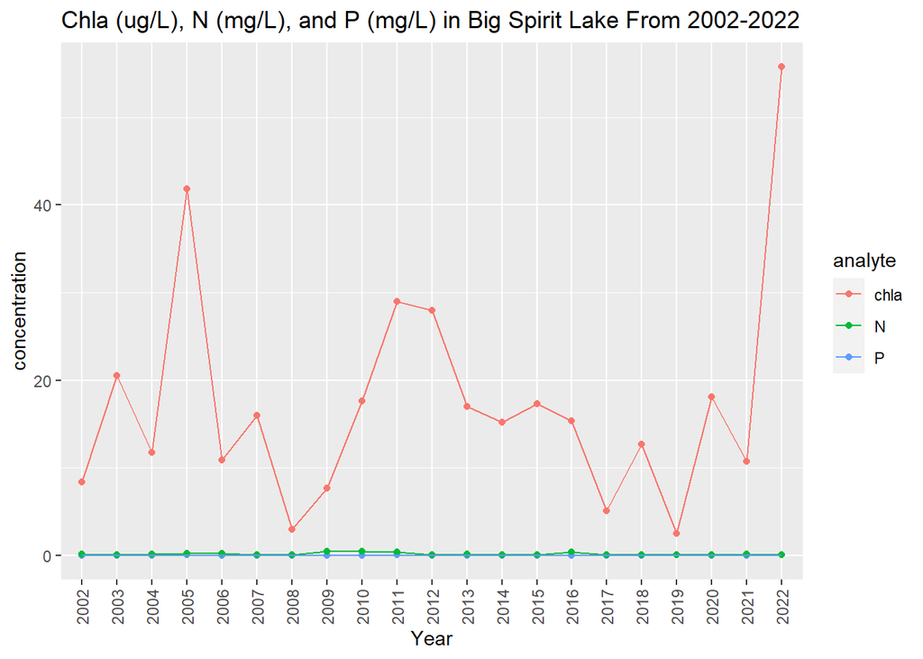

```r
bslNPChla_plot <- ggplot(bslNPChla, aes(x=Year, y=concentration, group=analyte, color=analyte)) + geom_point() + geom_line() + theme(axis.text.x = element_text(angle = 90, vjust = 0.5, hjust=1)) + ggtitle("Chla (ug/L), N (mg/L), and P (mg/L) in Big Spirit Lake From 2002-2022")

bslNPChla_plot
```

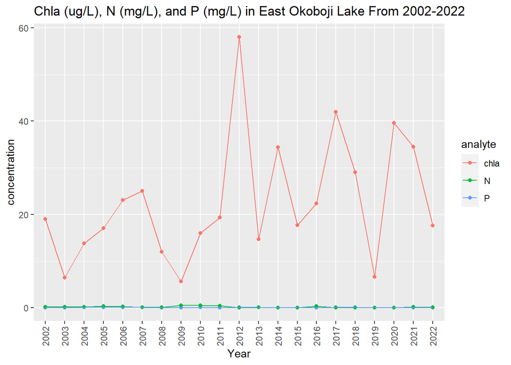

```r
eolNPChla_plot <- ggplot(eolNPChla, aes(x=Year, y=concentration, group=analyte, color=analyte)) + geom_point() + geom_line() + theme(axis.text.x = element_text(angle = 90, vjust = 0.5, hjust=1)) + ggtitle("Chla (ug/L), N (mg/L), and P (mg/L) in East Okoboji Lake From 2002-2022")

eolNPChla_plot
```

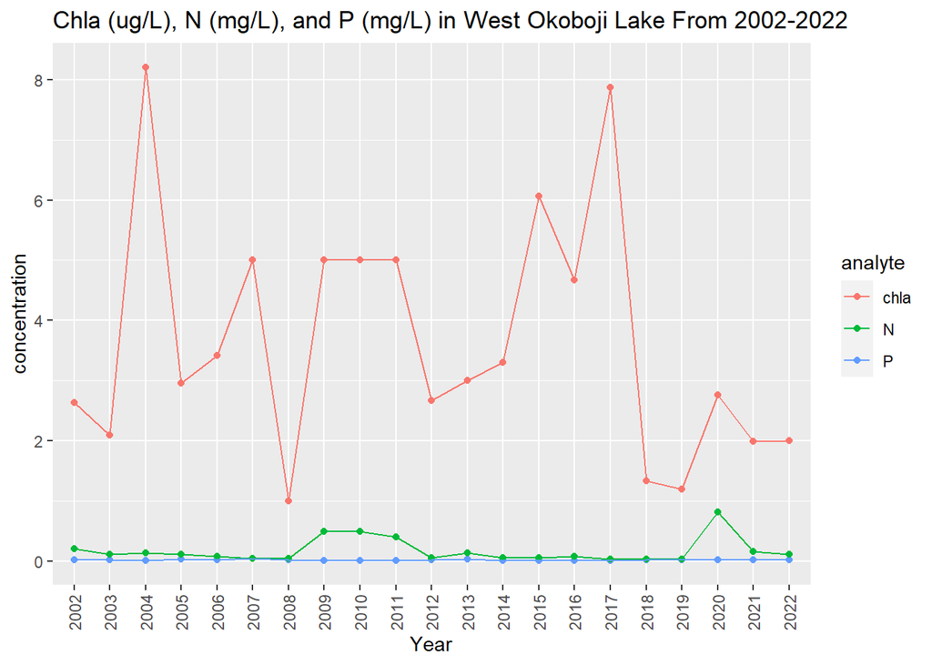

```r
wolNPChla_plot <- ggplot(wolNPChla, aes(x=Year, y=concentration, group=analyte, color=analyte)) + geom_point() + geom_line() + theme(axis.text.x = element_text(angle = 90, vjust = 0.5, hjust=1)) + ggtitle("Chla (ug/L), N (mg/L), and P (mg/L) in West Okoboji Lake From 2002-2022")

wolNPChla_plot
```

- **Looking at all three analytes on the same graph, it appears that N increases during periods of chl-a increase, but it is difficult to visualize a relationship.**

I then plotted N vs chl-a and P vs chl-a to more easily visualize any possible relationships:

- Formatted data to get separate columns for N, P, chl-a:

```r
bslNPChla_wide <- inner_join(bsl_P, bsl_N, by = c("Date", "unit", "Year", "name")) %>% inner_join(bsl_chla_1, by = c("Date", "Year", "name")) %>% group_by(Year) %>% summarise(P = mean(P), N = mean(N), chla = mean(chla))

eolNPChla_wide <- inner_join(eol_P, eol_N, by = c("Date", "unit", "Year", "name")) %>% inner_join(eol_chla_1, by = c("Date", "Year", "name")) %>% group_by(Year) %>% summarise(P = mean(P), N = mean(N), chla = mean(chla))

wolNPChla_wide <- inner_join(wol_P, wol_N, by = c("Date", "unit", "Year", "name")) %>% inner_join(wol_chla_1, by = c("Date", "Year", "name")) %>% group_by(Year) %>% summarise(P = mean(P), N = mean(N), chla = mean(chla))

head(bslNPChla_wide)
```

```
## # A tibble: 6 × 4
##   Year       P     N  chla
##   <chr>  <dbl> <dbl> <dbl>
## 1 2002  0.0443 0.157  8.37
## 2 2003  0.045  0.12  20.6
## 3 2004  0.0417 0.137 11.8
## 4 2005  0.0558 0.216 41.8
## 5 2006  0.048  0.274 10.9
## 6 2007  0.05   0.127 16
```

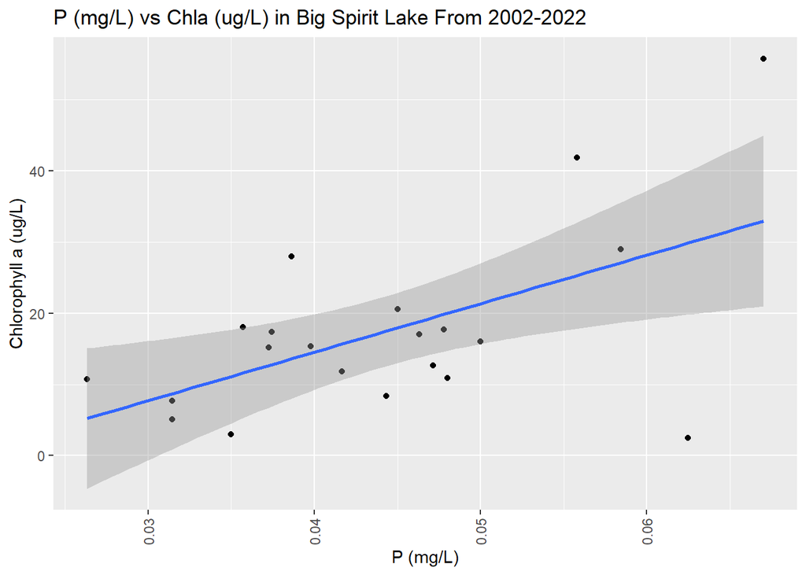

```r
bslNPChla_plot_2 <- ggplot(bslNPChla_wide, aes(x=P, y=chla)) + geom_point() + theme(axis.text.x = element_text(angle = 90, vjust = 0.5, hjust=1)) + ggtitle("P (mg/L) vs Chla (ug/L) in Big Spirit Lake From 2002-2022") + geom_smooth(method=lm) + xlab("P (mg/L)") + ylab("Chlorophyll a (ug/L)")

bslNPChla_plot_2
```

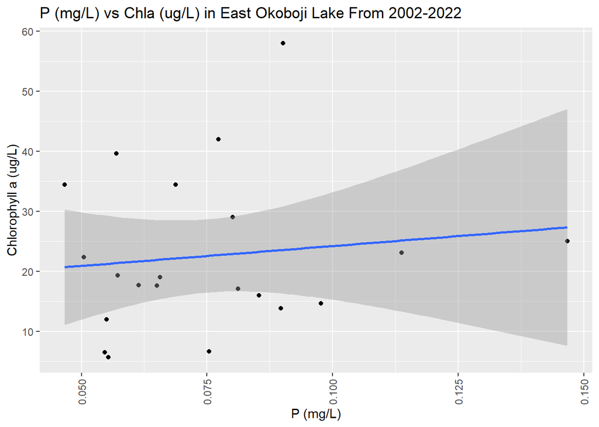

```r
eolNPChla_plot_2 <- ggplot(eolNPChla_wide, aes(x=P, y=chla)) + geom_point() + theme(axis.text.x = element_text(angle = 90, vjust = 0.5, hjust=1)) + ggtitle("P (mg/L) vs Chla (ug/L) in East Okoboji Lake From 2002-2022") + geom_smooth(method=lm) + xlab("P (mg/L)") + ylab("Chlorophyll a (ug/L)")

eolNPChla_plot_2
```

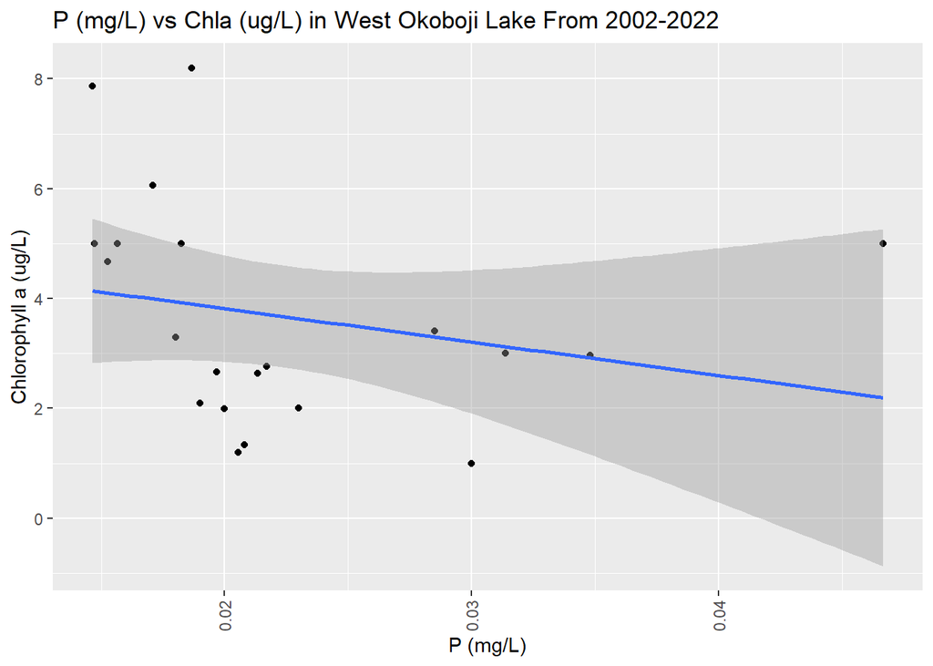

```r
wolNPChla_plot_2 <- ggplot(wolNPChla_wide, aes(x=P, y=chla)) + geom_point() + theme(axis.text.x = element_text(angle = 90, vjust = 0.5, hjust=1)) + ggtitle("P (mg/L) vs Chla (ug/L) in West Okoboji Lake From 2002-2022") + geom_smooth(method=lm) + xlab("P (mg/L)") + ylab("Chlorophyll a (ug/L)")

wolNPChla_plot_2
```

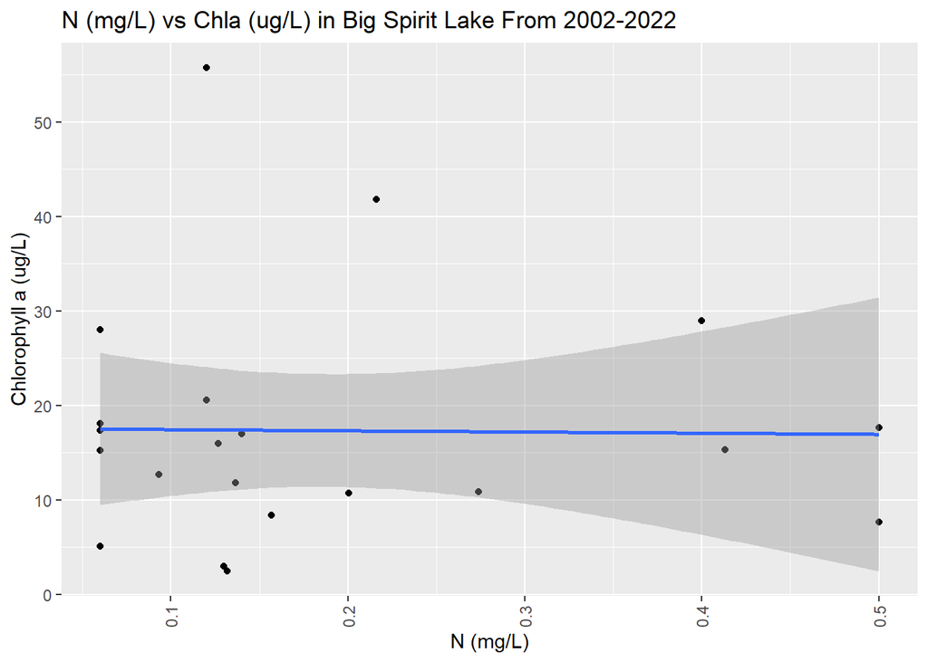

```r
bslNPChla_plot_3 <- ggplot(bslNPChla_wide, aes(x=N, y=chla)) + geom_point() + theme(axis.text.x = element_text(angle = 90, vjust = 0.5, hjust=1)) + ggtitle("N (mg/L) vs Chla (ug/L) in Big Spirit Lake From 2002-2022") + geom_smooth(method=lm) + xlab("N (mg/L)") + ylab("Chlorophyll a (ug/L)")

bslNPChla_plot_3
```

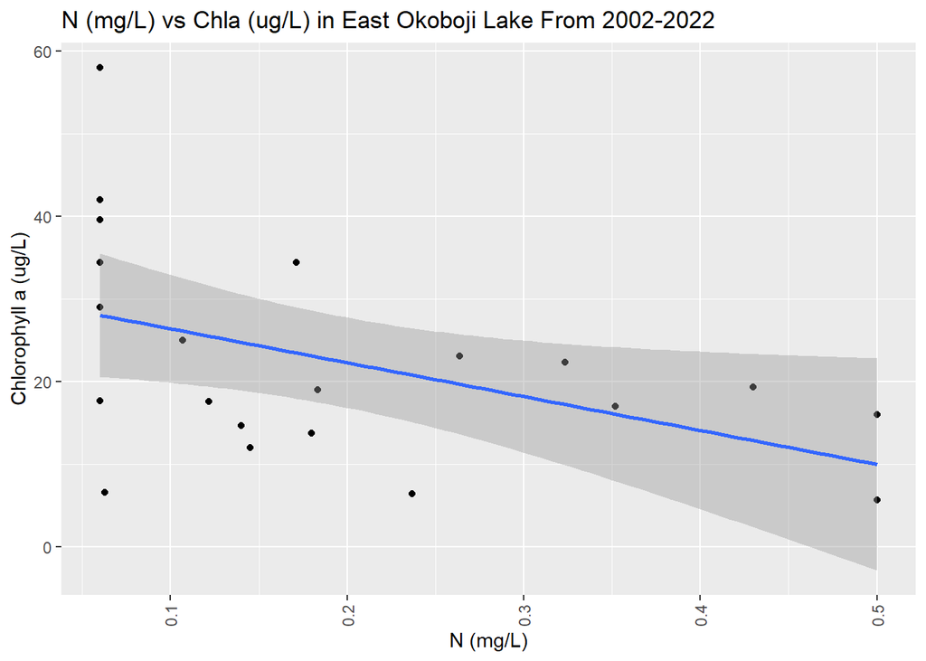

```r
eolNPChla_plot_3 <- ggplot(eolNPChla_wide, aes(x=N, y=chla)) + geom_point() + theme(axis.text.x = element_text(angle = 90, vjust = 0.5, hjust=1)) + ggtitle("N (mg/L) vs Chla (ug/L) in East Okoboji Lake From 2002-2022") + geom_smooth(method=lm) + xlab("N (mg/L)") + ylab("Chlorophyll a (ug/L)")

eolNPChla_plot_3
```

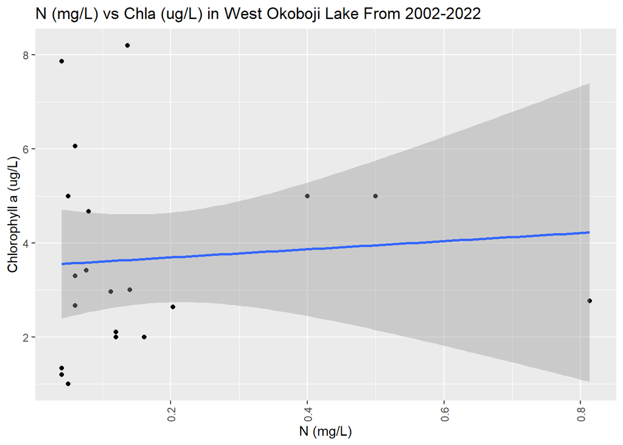

```r
wolNPChla_plot_3 <- ggplot(wolNPChla_wide, aes(x=N, y=chla)) + geom_point() + theme(axis.text.x = element_text(angle = 90, vjust = 0.5, hjust=1)) + ggtitle("N (mg/L) vs Chla (ug/L) in West Okoboji Lake From 2002-2022") + geom_smooth(method=lm) + xlab("N (mg/L)") + ylab("Chlorophyll a (ug/L)")

wolNPChla_plot_3
```

**Overall, the data appears to vary by lake, with Big Spirit Lake showing a positive correlation between P and chl-a concentrations and no noticable correlation between N and chl-a concentrations. East Okoboji Lake showed a postitive correlation between P and chl-a concentrations and a negative correlation between N and chl-a concentrations while West Okoboji Lake showed a negative correlation between P and chl-a concentrations and a slight positive correlation between N and chl-a concentrations.**

# **3.)**

Compare with Bachman’s result.

- For this question, I assume that Bachman’s result refers to data collected in the Iowa Great Lakes from 1971 to 1990, which is listed under the Bachman project/task.
- I then re-loaded the data as was done previously and filtered for the Bachman project code:

```r
bsl_bachman <- read.csv("big-spirit-lake.csv") %>% extract("sampleDate", c("Year", "Date"), regex = '(^[0-9]{4})\\D(.{5})') %>% filter(projectCode == "BACHMAN") #Big Spirit Lake
wol_bachman <- read.csv("west_okoboji_lake.csv") %>% extract("sampleDate", c("Year", "Date"), regex = '(^[0-9]{4})\\D(.{5})') %>% filter(projectCode == "BACHMAN") #West Okoboji Lake
eol_bachman <- read.csv("east_okoboji_lake.csv") %>% extract("sampleDate", c("Year", "Date"), regex = '(^[0-9]{4})\\D(.{5})') %>% filter(projectCode == "BACHMAN") #East Okoboji Lake

head(bsl_bachman) #inspect data format for one of the files
```

```
##   facilityID   siteID            name    county     huc8 type aquifer latitude
## 1          6 22300014 Big Spirit Lake Dickinson 10230003 Lake      NA 43.48076
## 2          6 22300014 Big Spirit Lake Dickinson 10230003 Lake      NA 43.48076
## 3          6 22300014 Big Spirit Lake Dickinson 10230003 Lake      NA 43.48076
## 4          6 22300014 Big Spirit Lake Dickinson 10230003 Lake      NA 43.48076
## 5          6 22300014 Big Spirit Lake Dickinson 10230003 Lake      NA 43.48076
## 6          6 22300014 Big Spirit Lake Dickinson 10230003 Lake      NA 43.48076
##   longitude Year  Date projectCode       cas_rn                  analyte
## 1 -95.08332 1990 05-25     BACHMAN DEPTH-SECCHI Depth, Secchi disk depth
## 2 -95.08332 1990 05-25     BACHMAN   TEMP-WATER       Temperature, water
## 3 -95.08332 1990 05-25     BACHMAN     479-61-8            Chlorophyll a
## 4 -95.08332 1990 05-25     BACHMAN NIT-NUTRIENT        Nutrient-nitrogen
## 5 -95.08332 1990 05-25     BACHMAN  PHOSP-PHOSP  Total Phosphorus (AS P)
## 6 -95.08332 1990 05-25     BACHMAN         TFSS   Fixed suspended solids
##     fraction relDepth  result  unit detect detectLimit quantFlag quantLimit
## 1      Total           5.0000     m   True          NA                   NA
## 2      Total          16.6000 deg C   True          NA                   NA
## 3 Filterable           6.1000  ug/l   True          NA                   NA
## 4      Total           1.0000  mg/l   True          NA                   NA
## 5      Total           0.0459  mg/l   True          NA                   NA
## 6      Total           0.0000  mg/l   True          NA                   NA
##    method   colMethod resultType matrix medium qualFlag remark
## 1 Unknown BACHMANLAKE     Actual     MW  Water       NA     NA
## 2 Unknown BACHMANLAKE     Actual     MW  Water       NA     NA
## 3 Unknown BACHMANLAKE     Actual     SW  Water       NA     NA
## 4 Unknown BACHMANLAKE     Actual     SW  Water       NA     NA
## 5 Unknown BACHMANLAKE     Actual     SW  Water       NA     NA
## 6 Unknown BACHMANLAKE     Actual     SW  Water       NA     NA
```

I then filtered out any analytes that were not Chl-a, N, or P:

```r
bsl_bachman_chla <- filter(bsl_bachman, grepl('Chlorophyll', analyte)) %>% rename(chla = result) %>% select(c(name, Year, Date, chla, unit, analyte))
eol_bachman_chla <- filter(eol_bachman, grepl('Chlorophyll', analyte)) %>% rename(chla = result) %>% select(c(name, Year, Date, chla, unit, analyte))
wol_bachman_chla <- filter(wol_bachman, grepl('Chlorophyll', analyte)) %>% rename(chla = result) %>% select(c(name, Year, Date, chla, unit, analyte))

bsl_bachman_P <- filter(bsl_bachman, grepl('Total Phosphorus', analyte)) %>% rename(P = result) %>% select(c(name, Year, Date, P, unit, analyte))
eol_bachman_P <- filter(eol_bachman, grepl('Total Phosphorus', analyte)) %>% rename(P = result) %>% select(c(name, Year, Date, P, unit, analyte))
wol_bachman_P <- filter(wol_bachman, grepl('Total Phosphorus', analyte)) %>% rename(P = result) %>% select(c(name, Year, Date, P, unit, analyte))

bsl_bachman_N <- filter(bsl_bachman, grepl('Inorganic nitrogen', analyte)) %>% rename(N = result) %>% select(c(name, Year, Date, N, unit, analyte))
eol_bachman_N <- filter(eol_bachman, grepl('Inorganic nitrogen', analyte)) %>% rename(N = result) %>% select(c(name, Year, Date, N, unit, analyte))
wol_bachman_N <- filter(wol_bachman, grepl('Inorganic nitrogen', analyte)) %>% rename(N = result) %>% select(c(name, Year, Date, N, unit, analyte))

bsl_bachman_NPchla <- left_join(bsl_bachman_P, bsl_bachman_N, by = c("Date", "Year", "name")) %>% left_join(bsl_bachman_chla, by = c("Date", "Year", "name"))

eol_bachman_NPchla <- left_join(eol_bachman_P, bsl_bachman_N, by = c("Date", "Year", "name")) %>% right_join(eol_bachman_chla, by = c("Date", "Year", "name")) %>% drop_na(P)

wol_bachman_NPchla <- full_join(wol_bachman_P, bsl_bachman_N, by = c("Date", "Year", "name")) %>% left_join(wol_bachman_chla, by = c("Date", "Year", "name")) %>% drop_na(chla)
```

- In this case, I only looked at P vs Chl-a due to a lack of N data:

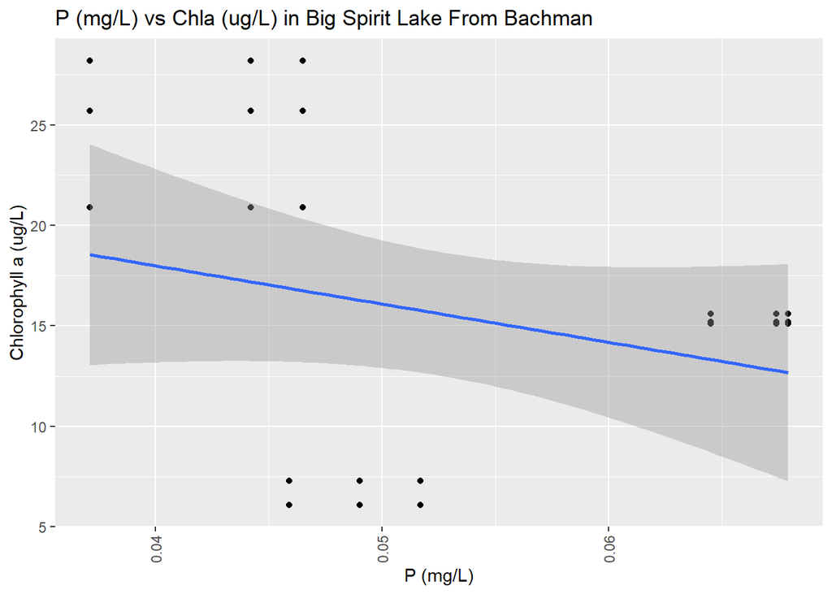

```r
bslNPChla_plot_bachman <- ggplot(bsl_bachman_NPchla, aes(x=P, y=chla)) + geom_point() + theme(axis.text.x = element_text(angle = 90, vjust = 0.5, hjust=1)) + ggtitle("P (mg/L) vs Chla (ug/L) in Big Spirit Lake From Bachman") + geom_smooth(method=lm) + xlab("P (mg/L)") + ylab("Chlorophyll a (ug/L)")

bslNPChla_plot_bachman
```

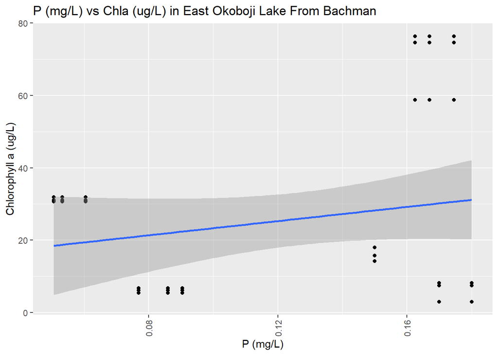

```r
eolNPChla_plot_bachman <- ggplot(eol_bachman_NPchla, aes(x=P, y=chla)) + geom_point() + theme(axis.text.x = element_text(angle = 90, vjust = 0.5, hjust=1)) + ggtitle("P (mg/L) vs Chla (ug/L) in East Okoboji Lake From Bachman") + geom_smooth(method=lm) + xlab("P (mg/L)") + ylab("Chlorophyll a (ug/L)")

eolNPChla_plot_bachman
```

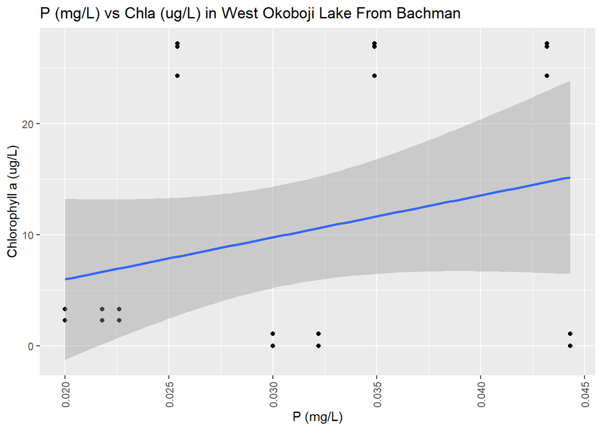

```r
wolNPChla_plot_bachman <- ggplot(data = wol_bachman_NPchla, aes(x=P, y=chla)) + geom_point() + theme(axis.text.x = element_text(angle = 90, vjust = 0.5, hjust=1)) + ggtitle("P (mg/L) vs Chla (ug/L) in West Okoboji Lake From Bachman") + geom_smooth(method=lm) + xlab("P (mg/L)") + ylab("Chlorophyll a (ug/L)")

wolNPChla_plot_bachman
```

**Bachman’s result indicates that P is negatively correlated with chlorophyll a in Big Spirit Lake and positively correlated in East and West Okoboji Lakes. For Big Sprit Lake, the trend in P vs. Chl-a was opposite that of the last 20 years while for East and West Okoboji Lakes, the trends were relatively consistent.**

…………………………………………………………………………………………….

# **4.)**

Explore if there is a relationship betwen CHl-a and SD (Secchi Depth)? Consider statistical metrics to evaluate how well a relationship describes the data.

- For this question, I took the Secchi Depth data from AquIA and joined it with the previously obtained Chl-a data for the past 20 years:

```r
bsl_SD <- filter(bsl, grepl('Secchi', analyte)) %>% rename(SD = result) %>% select(c(name, Year, Date, SD, unit, analyte))

eol_SD <- filter(eol, grepl('Secchi', analyte)) %>% rename(SD = result) %>% select(c(name, Year, Date, SD, unit, analyte))

wol_SD <- filter(wol, grepl('Secchi', analyte)) %>% rename(SD = result) %>% select(c(name, Year, Date, SD, unit, analyte))
```

```r
bsl_SDchla <- inner_join(bsl_SD, bsl_chla_1, by = c("Date", "Year", "name")) %>% group_by(Year) %>% summarise(SD = mean(SD), chla = mean(chla))

eol_SDchla <- inner_join(eol_SD, eol_chla_1, by = c("Date", "Year", "name")) %>% group_by(Year) %>% summarise(SD = mean(SD), chla = mean(chla))

wol_SDchla <- inner_join(wol_SD, wol_chla_1, by = c("Date", "Year", "name")) %>% group_by(Year) %>% summarise(SD = mean(SD), chla = mean(chla))

head(bsl_SDchla) #inspect data for Big Spirit Lake
```

```
## # A tibble: 6 × 3
##   Year     SD  chla
##   <chr> <dbl> <dbl>
## 1 2002   1.87  8.37
## 2 2003   1.63 20.6
## 3 2004   1.52 11.8
## 4 2005   1.94 51.3
## 5 2006   2.09 10.9
## 6 2007   1.93 19.9
```

- Graphed SD vs Chlorophyll a in each of the Iowa Great Lakes:

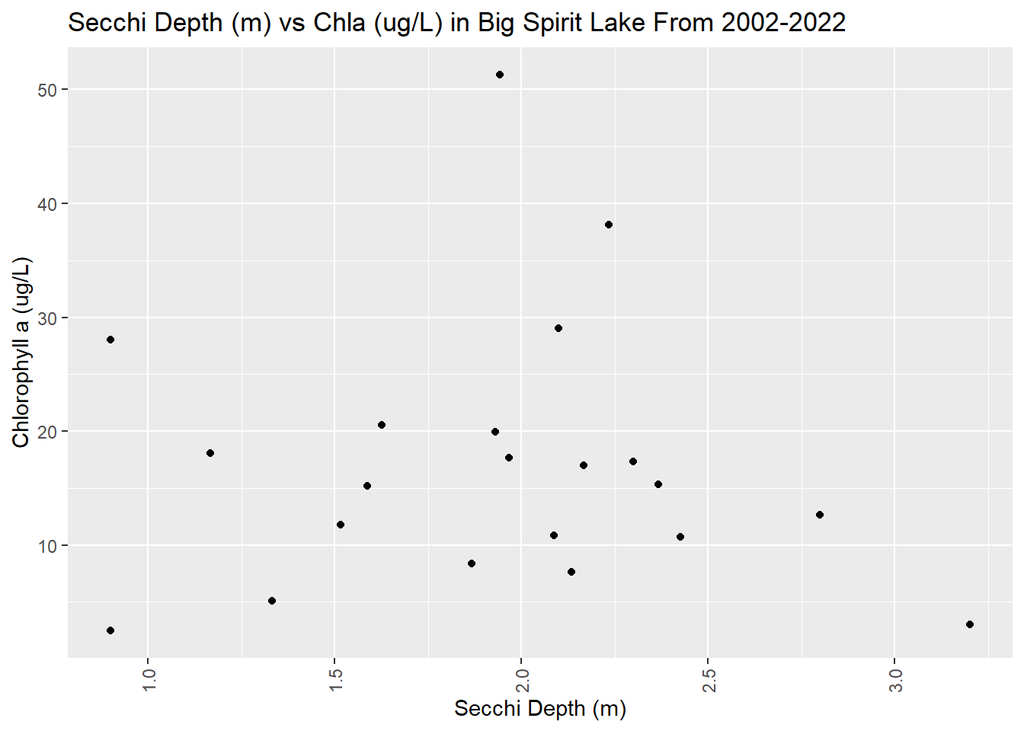

```r
bsl_SDchla_plot <- ggplot(bsl_SDchla, aes(x=SD, y=chla)) + geom_point() + theme(axis.text.x = element_text(angle = 90, vjust = 0.5, hjust=1)) + ggtitle("Secchi Depth (m) vs Chla (ug/L) in Big Spirit Lake From 2002-2022") + xlab("Secchi Depth (m)") + ylab("Chlorophyll a (ug/L)")

bsl_SDchla_plot
```

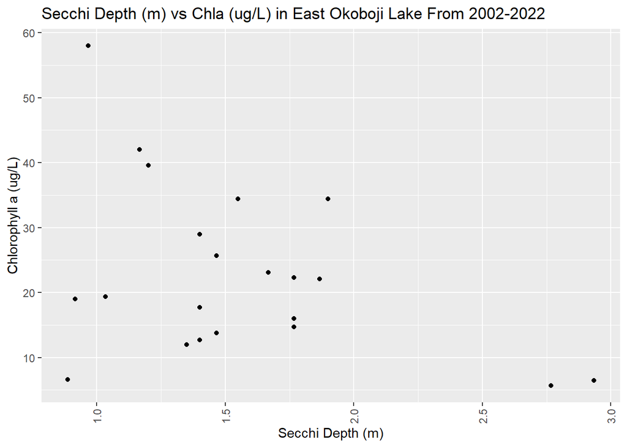

```r
eol_SDchla_plot <- ggplot(eol_SDchla, aes(x=SD, y=chla)) + geom_point() + theme(axis.text.x = element_text(angle = 90, vjust = 0.5, hjust=1)) + ggtitle("Secchi Depth (m) vs Chla (ug/L) in East Okoboji Lake From 2002-2022") + xlab("Secchi Depth (m)") + ylab("Chlorophyll a (ug/L)")

eol_SDchla_plot
```

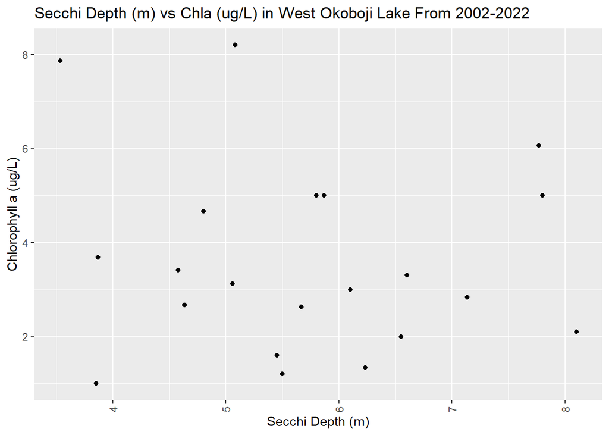

```r
wol_SDchla_plot <- ggplot(wol_SDchla, aes(x=SD, y=chla)) + geom_point() + theme(axis.text.x = element_text(angle = 90, vjust = 0.5, hjust=1)) + ggtitle("Secchi Depth (m) vs Chla (ug/L) in West Okoboji Lake From 2002-2022") + xlab("Secchi Depth (m)") + ylab("Chlorophyll a (ug/L)")

wol_SDchla_plot
```

- Semi-log and log-log plots for each lake:

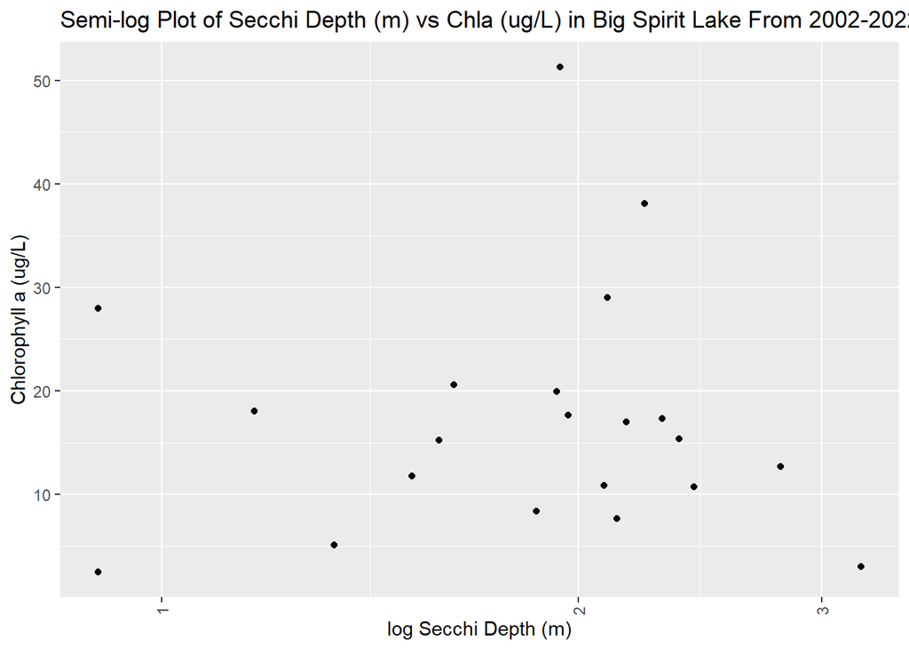

```r
bsl_SDchla_plot_semi <- ggplot(bsl_SDchla, aes(x=SD, y=chla)) + geom_point() + theme(axis.text.x = element_text(angle = 90, vjust = 0.5, hjust=1)) + ggtitle("Semi-log Plot of Secchi Depth (m) vs Chla (ug/L) in Big Spirit Lake From 2002-2022") + xlab("log Secchi Depth (m)") + ylab("Chlorophyll a (ug/L)") + scale_x_log10()

bsl_SDchla_plot_semi
```

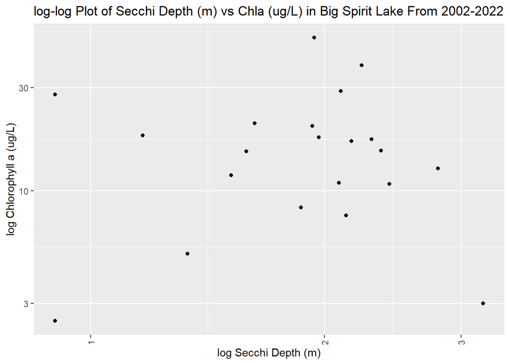

```r
bsl_SDchla_plot_log <- ggplot(bsl_SDchla, aes(x=SD, y=chla)) + geom_point() + theme(axis.text.x = element_text(angle = 90, vjust = 0.5, hjust=1)) + ggtitle("log-log Plot of Secchi Depth (m) vs Chla (ug/L) in Big Spirit Lake From 2002-2022") + xlab("log Secchi Depth (m)") + ylab("log Chlorophyll a (ug/L)") + scale_x_log10() + scale_y_log10()

bsl_SDchla_plot_log
```

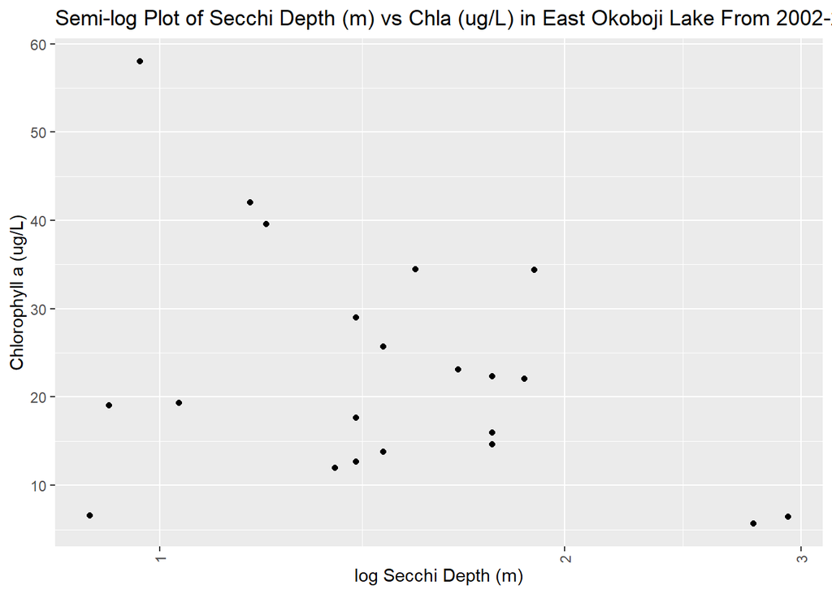

```r
eol_SDchla_plot_semi <- ggplot(eol_SDchla, aes(x=SD, y=chla)) + geom_point() + theme(axis.text.x = element_text(angle = 90, vjust = 0.5, hjust=1)) + ggtitle("Semi-log Plot of Secchi Depth (m) vs Chla (ug/L) in East Okoboji Lake From 2002-2022") + xlab("log Secchi Depth (m)") + ylab("Chlorophyll a (ug/L)") + scale_x_log10()

eol_SDchla_plot_semi
```

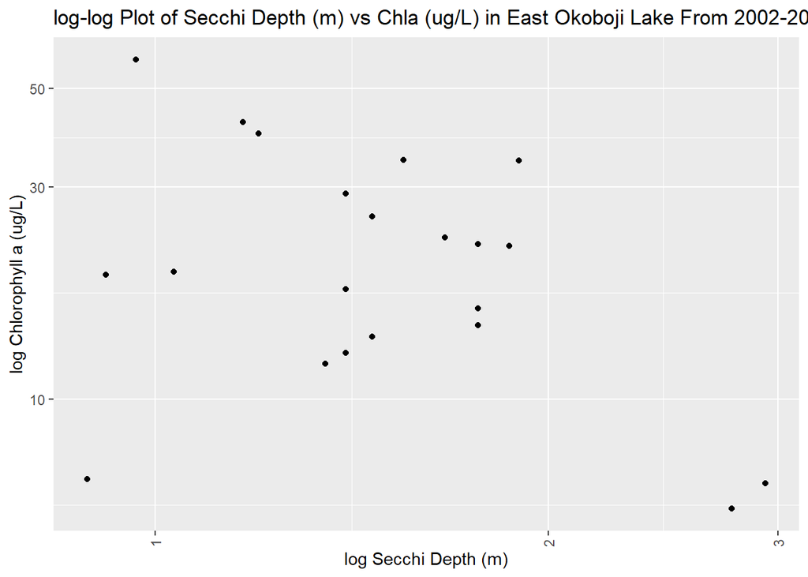

```r
eol_SDchla_plot_log <- ggplot(eol_SDchla, aes(x=SD, y=chla)) + geom_point() + theme(axis.text.x = element_text(angle = 90, vjust = 0.5, hjust=1)) + ggtitle("log-log Plot of Secchi Depth (m) vs Chla (ug/L) in East Okoboji Lake From 2002-2022") + xlab("log Secchi Depth (m)") + ylab("log Chlorophyll a (ug/L)") + scale_x_log10() + scale_y_log10()

eol_SDchla_plot_log
```

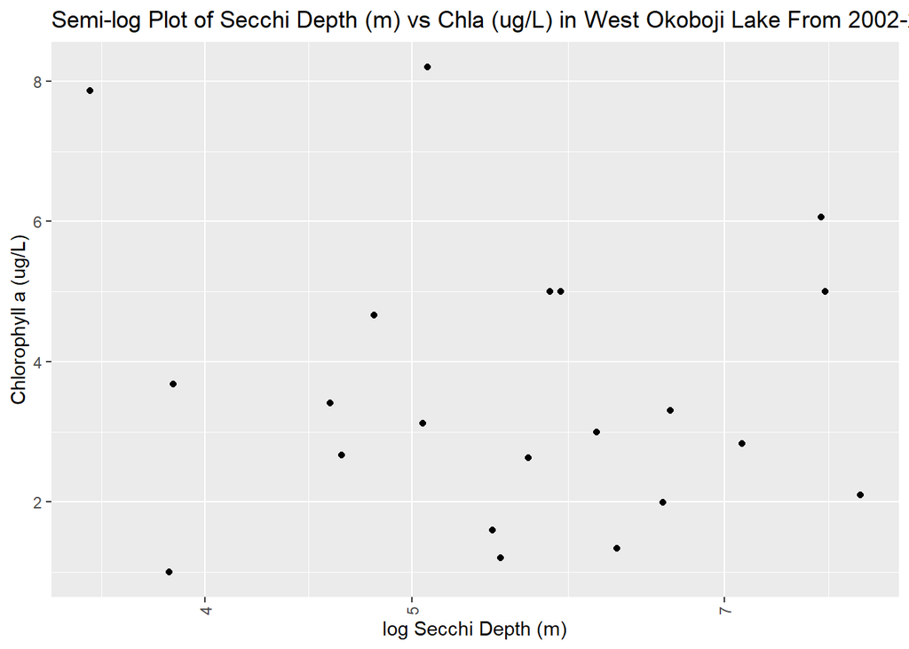

```r
wol_SDchla_plot_semi <- ggplot(wol_SDchla, aes(x=SD, y=chla)) + geom_point() + theme(axis.text.x = element_text(angle = 90, vjust = 0.5, hjust=1)) + ggtitle("Semi-log Plot of Secchi Depth (m) vs Chla (ug/L) in West Okoboji Lake From 2002-2022") + xlab("log Secchi Depth (m)") + ylab("Chlorophyll a (ug/L)") + scale_x_log10()

wol_SDchla_plot_semi
```

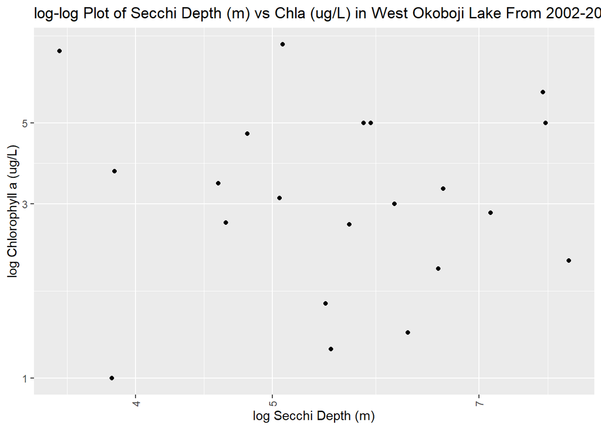

```r
wol_SDchla_plot_log <- ggplot(wol_SDchla, aes(x=SD, y=chla)) + geom_point() + theme(axis.text.x = element_text(angle = 90, vjust = 0.5, hjust=1)) + ggtitle("log-log Plot of Secchi Depth (m) vs Chla (ug/L) in West Okoboji Lake From 2002-2022") + xlab("log Secchi Depth (m)") + ylab("log Chlorophyll a (ug/L)") + scale_x_log10() + scale_y_log10()

wol_SDchla_plot_log
```

- First, I defined the power law function and plotted a log-log plot for Big Spirit Lake:

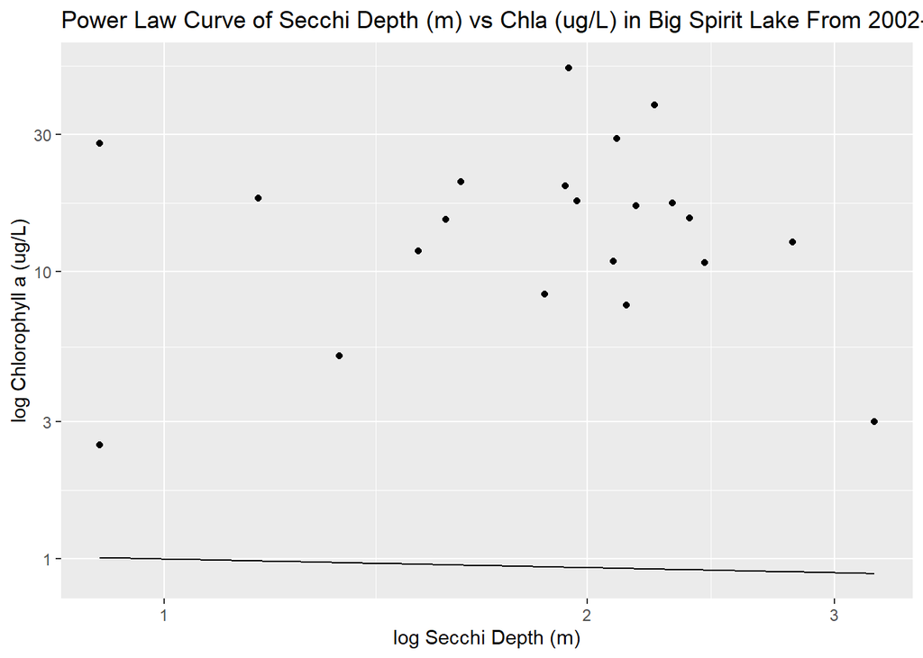

```r
x <- bsl_SDchla$SD
pwr <- function(x)x^-0.1
dat <- data.frame(x, y = pwr(x))

bsl_pwr <- ggplot(dat, aes(x = x, y = bsl_SDchla$chla)) +
  geom_point() + stat_function(fun = pwr) + scale_x_log10() + scale_y_log10() + ggtitle("Power Law Curve of Secchi Depth (m) vs Chla (ug/L) in Big Spirit Lake From 2002-2022") + xlab("log Secchi Depth (m)") + ylab("log Chlorophyll a (ug/L)")

bsl_pwr
```

- East Okoboji Lake:

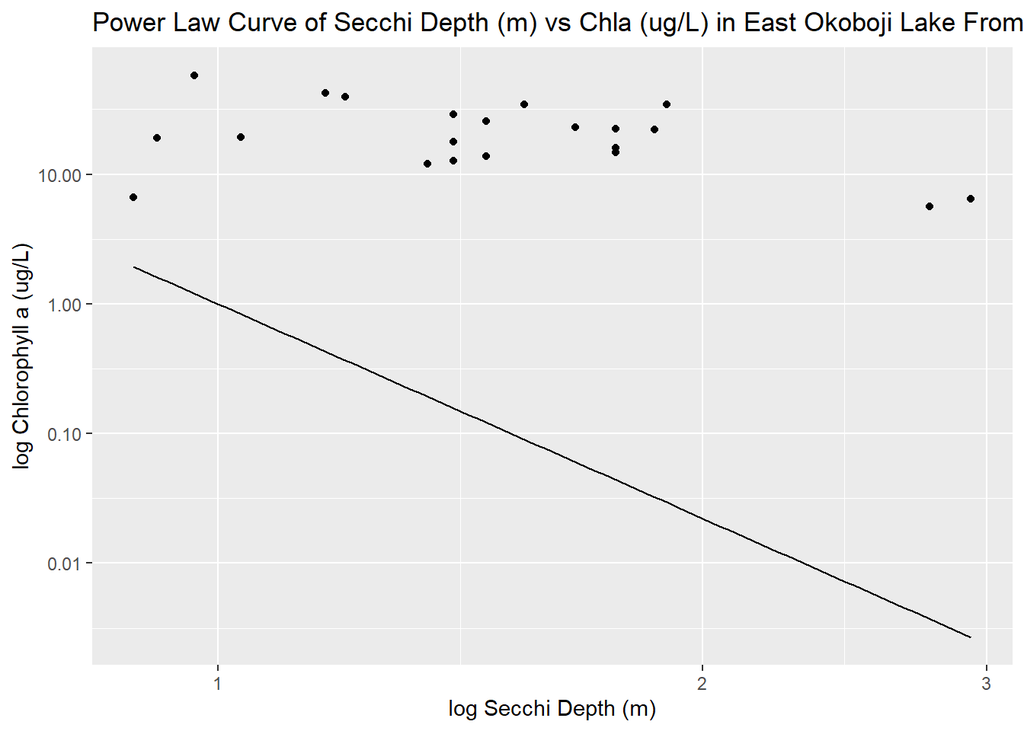

```r
x <- eol_SDchla$SD
pwr <- function(x)x^-5.5
dat <- data.frame(x, y = pwr(x))

eol_pwr <- ggplot(dat, aes(x = x, y = eol_SDchla$chla)) +
  geom_point() + stat_function(fun = pwr) + scale_x_log10() + scale_y_log10() + ggtitle("Power Law Curve of Secchi Depth (m) vs Chla (ug/L) in East Okoboji Lake From 2002-2022") + xlab("log Secchi Depth (m)") + ylab("log Chlorophyll a (ug/L)")

eol_pwr
```

- West Okoboji Lake:

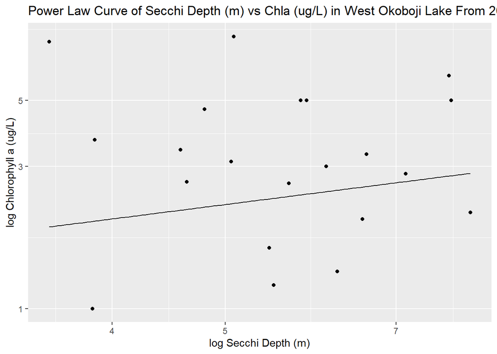

```r
x <- wol_SDchla$SD
pwr <- function(x)x^0.5
dat <- data.frame(x, y = pwr(x))

wol_pwr <- ggplot(dat, aes(x = x, y = wol_SDchla$chla)) +
  geom_point() + stat_function(fun = pwr) + scale_x_log10() + scale_y_log10() + ggtitle("Power Law Curve of Secchi Depth (m) vs Chla (ug/L) in West Okoboji Lake From 2002-2022") + xlab("log Secchi Depth (m)") + ylab("log Chlorophyll a (ug/L)")

wol_pwr
```